# RNA-seq downstream analysis

# Analysis summary

**GSE231397: estradiol response in MCF-7 cells**  
**Data status:** GSE231397: 1 nM E2 vs vehicle (24 h)

This report starts from a declared integer gene-count matrix; it does not perform read alignment or gene quantification. All comparisons come from the supplied contrast table.

Contrast-level result ledger summary

| contrast | input_rows | retained_rows | finite_pvalue | finite_padj | significant | increased | decreased | all_zero | low_count_filtered | unavailable | independent_filtered | tested_nonsignificant | alpha | p_adjust_method | independent_filtering | filter_threshold | bh_scope |
| --- | --- | --- | --- | --- | --- | --- | --- | --- | --- | --- | --- | --- | --- | --- | --- | --- | --- |
| E2_vs_vehicle | 39376 | 20488 | 20488 | 14530 | 2570 | 1499 | 1071 | 11909 | 6979 | 0 | 5958 | 11960 | 0.05 | BH | TRUE | 23.9656 | one DESeq2 contrast among retained rows passing the selected independent-filter threshold with finite raw p-values |

`input_rows` is the full input feature universe. A missing adjusted p-value is never called non-significant: `all_zero`, `low_count_filtered`, `unavailable`, and `independent_filtered` remain separate from `tested_nonsignificant`. Benjamini-Hochberg adjustment and DESeq2 independent filtering are applied separately within each declared contrast.

# Inputs and design

Resolved run metadata

| field | value |
| --- | --- |
| project | GSE231397: estradiol response in MCF-7 cells |
| data_status | GSE231397: 1 nM E2 vs vehicle (24 h) |
| design | ~ condition |
| fdr | 0.05 |
| minimum_total_count | 10 |
| input_genes | 39376 |
| retained_genes | 20488 |
| samples | 6 |
| contrasts | 1 |
| generated_utc | 2026-10-02 22:30:58 UTC |

Sample metadata

|  | condition | biological_replicate | treatment |
| --- | --- | --- | --- |
| GSM7270183 | vehicle | 1 | DMSO |
| GSM7270188 | vehicle | 2 | DMSO |
| GSM7270193 | vehicle | 3 | DMSO |
| GSM7270186 | estradiol | 1 | 1 nM E2 |
| GSM7270190 | estradiol | 2 | 1 nM E2 |
| GSM7270195 | estradiol | 3 | 1 nM E2 |

Declared comparisons

| label | factor | numerator | denominator |
| --- | --- | --- | --- |
| E2_vs_vehicle | condition | estradiol | vehicle |

Library and normalization summary

| sample_id | library_size | detected_genes | size_factor |
| --- | --- | --- | --- |
| GSM7270183 | 18286128 | 23102 | 0.975 |
| GSM7270188 | 15963742 | 22854 | 0.863 |
| GSM7270193 | 19560818 | 23163 | 1.013 |
| GSM7270186 | 20243194 | 23164 | 1.065 |
| GSM7270190 | 21316977 | 23407 | 1.136 |
| GSM7270195 | 19594500 | 23089 | 0.995 |

Genes with total count below 10 are excluded from model fitting but retained in each result ledger. The design is ~ condition; categorical metadata with numeric-only codes are rejected to avoid accidental continuous-variable semantics.

# Sample-level diagnostics

PCA uses the 500 highest-variance variance-stabilized genes. The correlation matrix uses every retained transformed gene and prints Pearson coefficients in the figure and downloadable table.

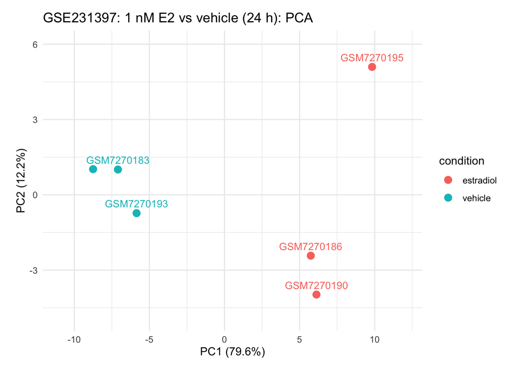

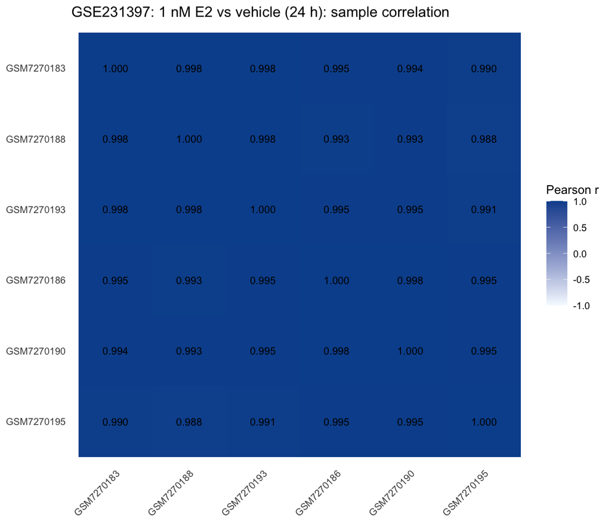

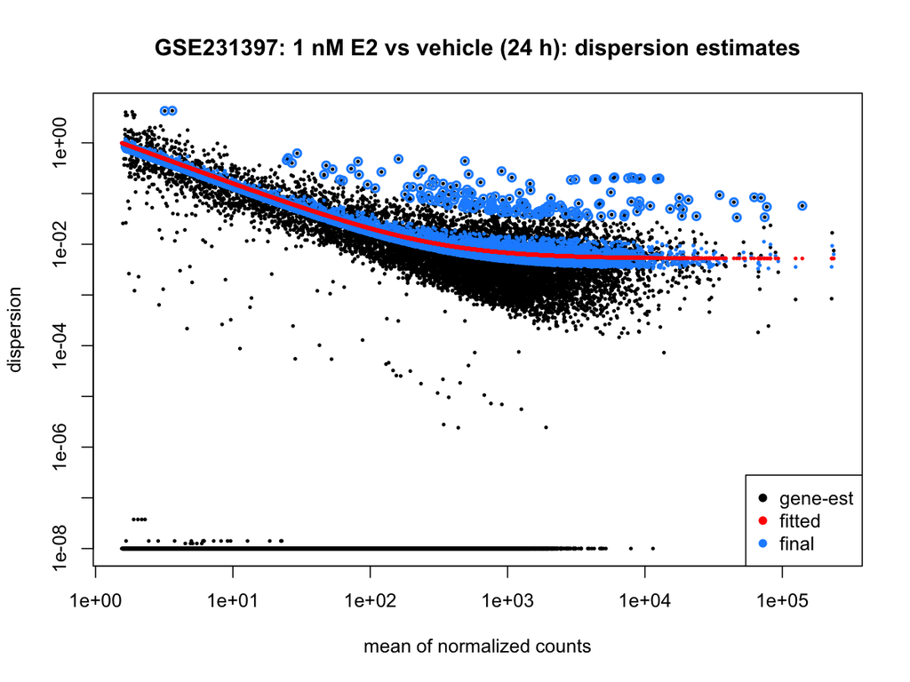

# Differential expression

## E2_vs_vehicle

| contrast | input_rows | retained_rows | finite_pvalue | finite_padj | significant | increased | decreased | all_zero | low_count_filtered | unavailable | independent_filtered | tested_nonsignificant | alpha | p_adjust_method | independent_filtering | filter_threshold | bh_scope |
| --- | --- | --- | --- | --- | --- | --- | --- | --- | --- | --- | --- | --- | --- | --- | --- | --- | --- |
| E2_vs_vehicle | 39376 | 20488 | 20488 | 14530 | 2570 | 1499 | 1071 | 11909 | 6979 | 0 | 5958 | 11960 | 0.05 | BH | TRUE | 23.9656 | one DESeq2 contrast among retained rows passing the selected independent-filter threshold with finite raw p-values |

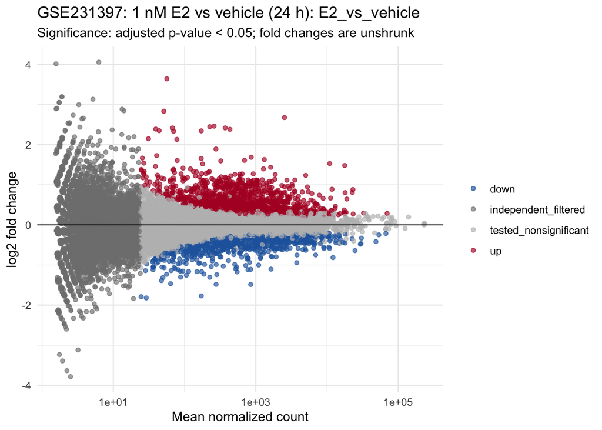

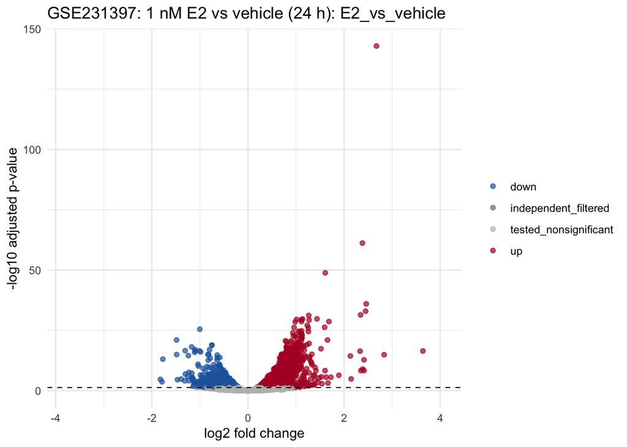

# Optional functional enrichment

When enabled, up- and down-regulated genes are mapped separately to Entrez IDs. Mapping coverage is exported for every direction. Empty, completely unmapped, and partially mapped selections produce explicit statuses and schema-stable tables rather than biological claims.

Enrichment was not requested in this configuration.

# Downloads and reproducibility

This saved portfolio snapshot links only to compact tracked results. Full tables are regenerated under the configured output directory.

- Contrast summary
- Published-target concordance

The manifests record resolved input paths and SHA-256 hashes, analysis-code hashes, resolved configuration, software versions, warnings, and the full R session. These are a transparent run record, not a claim that the environment is automatically restorable.